# 🚢 Trade and employment

Source: [`vignettes/articles/trade-employment.Rmd`](https://github.com/Linbojun99/faofishingreport/blob/main/vignettes/articles/trade-employment.Rmd)

**🧩 Extension.** This article uses FAO datasets other than global capture production (trade, employment, and the catch by division of regional fishery bodies). These functions are an extension of the package: they are not part of the Word report written by `fao_report()`.

Besides the catch, FAO publishes the **trade** of aquatic products and the **employment** in fisheries and aquaculture on the same data index (https://www.fao.org/fishery/static/Data/). Both can be joined to the catch data: trade by country, ISSCAAP species group and year, employment by country and year. This article shows the functions that do it, what the data can and cannot say, and the published work they follow.

## 🚢 Trade data

`load_fao_trade()` downloads the newest release of the FAO trade statistics the first time (16 MB; converting takes about ten seconds), keeps it in the data folder and returns one row per country, commodity, flow and year:

```r
trade <- load_fao_trade()
norway <- subset(trade, Country..Name. == "Norway" & Trade.flow == "Exports" & Year == 2024)
head(norway[order(-norway$Value), c("Commodity..Name.", "ISSCAAP.group..Name.", "Quantity", "Value")])
```

| Column | Meaning |
| --- | --- |
| `Country..Name.` | Reporting country, named as in the catch data |
| `Commodity..Code.`, `Commodity..Name.` | Commodity of the ISSCFC classification (about 1,200 in use) |
| `ISSCAAP.group..Code.`, `ISSCAAP.group..Name.` | The ISSCAAP species group of the commodity, as in the catch data |
| `Trade.flow` | “Exports”, “Imports” or “Re-exports” |
| `Quantity` | Tonnes of **product weight** (fillets, frozen fish, fishmeal, …), not live weight |
| `Value` | Thousand US dollars (exports usually FOB, imports CIF) |
| `Quantity.Type`, `Value.Type` | “actual”, “estimate”, “partner data” (taken from the reports of trade partners), … |

Four things to keep in mind (FAO metadata of the release):

- **Product weight.** A tonne of fillets comes from two to three tonnes of fish, a tonne of fishmeal from four to five. FAO publishes no conversion factors with the data.
- **Caught or farmed?** A commodity does not tell. The two largest export groups in 2024, salmons and shrimps, are mostly farmed.
- **Re-exports** are reported by few countries (26 in 2024, not China), so most are counted as exports.
- **Partners.** Catch landed abroad by a country’s vessels counts as its export. Trade by partner country (FI_Trade_Partners) starts only in 2019 and is not read by the package.

## 🐟 Which species groups can be compared with the catch

Because trade does not separate caught from farmed products, `catch_trade()` compares only the ISSCAAP groups that are **mostly caught**: capture at least 90% of their world production (capture and aquaculture) in every year analysed. `fao_capture_groups()` gives the shares, from the FAO global production data built into the package:

```r
groups <- fao_capture_groups()
groups$capture_pct_min <- round(groups$capture_pct_min, 1)
groups[groups$capture_pct_min >= 75, c("isscaap_code", "isscaap_en", "capture_pct_min", "year_min", "counted")]
```

```
#>    isscaap_code                           isscaap_en capture_pct_min year_min
#> 7            24                                Shads            99.5     2006
#> 9            31           Flounders, halibuts, soles            80.3     2024
#> 10           32                Cods, hakes, haddocks            99.7     2009
#> 11           33         Miscellaneous coastal fishes            76.2     2024
#> 12           34        Miscellaneous demersal fishes            98.8     2007
#> 13           35        Herrings, sardines, anchovies           100.0     2021
#> 14           36           Tunas, bonitos, billfishes            99.1     2022
#> 15           37         Miscellaneous pelagic fishes            95.6     2023
#> 16           38              Sharks, rays, chimaeras           100.0     1976
#> 17           39         Marine fishes not identified            89.7     2024
#> 19           42                   Crabs, sea-spiders            77.2     2020
#> 20           43        Lobsters, spiny-rock lobsters            98.9     2024
#> 21           44           King crabs, squat-lobsters            99.8     2022
#> 23           46        Krill, planktonic crustaceans           100.0     1976
```

[output cut: 21 more lines]

From 1976 to 2024, 13 groups count: cods, herrings and sardines, tunas, miscellaneous pelagic and demersal fishes, sharks, shads, lobsters, king crabs, krill, miscellaneous marine crustaceans, squids and octopuses, and horseshoe crabs. They held 36% of the value of world exports in 2024. Shrimps (capture below 90% from 1986), crabs (2000), flounders (2004) and “Marine fishes not identified” (89.7% in 2022-2024) do not. `min_capture_pct` and `years` change the rule; shrimps, for example, count for 1976-1985.

## ⚖️ Catch and trade of a country: catch_trade()

```r
catch_trade(c("Norway", "Iceland", "Peru", "Thailand"), trade = trade, label = "four")
catch_trade("Norway", trade = trade)          # also one panel per species group
```

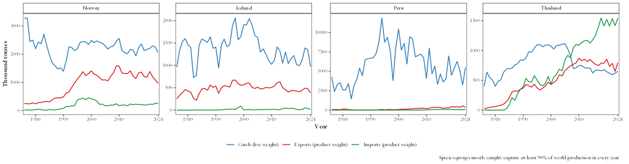

The table `yearly` of each country and year gives:

| Column | Meaning |
| --- | --- |
| `catch_tonnes` | Catch of the groups compared (all FAO areas; live weight) |
| `export_tonnes`, `import_tonnes`, `reexport_tonnes` | Trade of the same groups (product weight) |
| `export_value`, `import_value`, `export_unit_value` | Thousand USD; USD per kg of product |
| `export_catch_pct` | Exports (product weight) as % of the catch (live weight) |
| `counted_catch_pct`, `counted_export_value_pct` | How much of the country’s catch and export value the groups compared hold |
| `estimated_export_value_pct` | Share of the export value estimated or taken from partner reports |
| `meal_oil_export_tonnes` | Fishmeal and fish oil not assigned to a group compared (see below) |

In 2024:

| Country | Catch of the groups compared (t) | Exports (t, product weight) | Exports / catch | Share of the catch compared | Share of the export value compared |
| --- | --- | --- | --- | --- | --- |
| Norway | 2,061,767 | 962,671 | 47% | 89% | 19% |
| Iceland | 970,014 | 384,696 | 40% | 96% | 64% |
| Peru | 5,486,981 | 345,460 | 6% | 95% | 20% |
| Thailand | 651,720 | 797,282 | 122% | 42% | 55% |

- **Norway** exports about half of its catch of these groups (in product weight, so more in live weight), but they are only a fifth of its export value: farmed salmon makes up three quarters.
- **Peru** seems to export little, because its catch is mostly anchoveta reduced to fishmeal, and FAO classes most fishmeal and fish oil as “Fishmeals, nei” and “Fish body oils, nei”, in the group “Marine fishes not identified”. The function reports them separately: Peru exported 1.06 million tonnes in 2024.
- **Thailand** exports more than it catches and imports more than it exports: it processes imported tuna. The function lists the groups and years where exports exceed the catch.

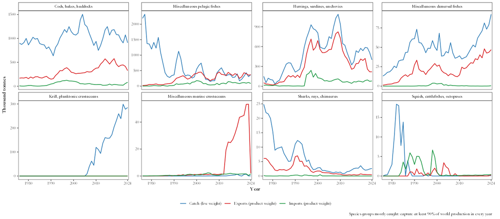

With your own **conversion factors** (e.g. from EUMOFA or FAO Fisheries Circular 847), trade is converted to live weight equivalent and the apparent supply (catch + imports − exports − re-exports) is calculated, as in food balance sheets:

```r
factors <- data.frame(commodity_code = c("034.1.5.2.19", "034.4.1.5.2.19"), factor = c(1.17, 2.6))
catch_trade("Norway", trade = trade, conversion = factors)
```

## 👥 Employment data

`load_fao_employment()` downloads the FAO statistics of the people employed in the primary sector (under 1 MB), by country, work area, working time, sex and year, from 1995, with FAO’s notes on individual countries:

```r
employment <- load_fao_employment()
notes <- attr(employment, "country_notes")
notes$note[notes$country_en == "China"]
```

The numbers are **people, not full-time equivalents**. Working time is unknown for 38% and sex for 41% of the data. FAO imputations make up about 30% of the data and half of the people in 2024. Processing and subsistence are not published. FAO first disseminated this dataset in 2026, revises the whole series between releases, and its country notes explain breaks and definitions. For example, China reports its part-time and occasional workers of fishing and aquaculture together as “Unspecified”, and its “Marine fishing, NEI” includes inland fishing in 1995-2006 and 2014-2020.

## 📊 People in fisheries and aquaculture: employment_summary()

```r
employment_summary(employment = employment)                                   # the world
employment_summary(c("Norway", "Peru", "China"), employment = employment, label = "three")
```

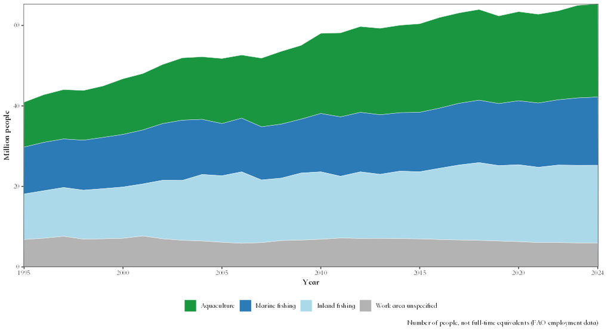

In 2024, 65.4 million people worked in fisheries and aquaculture: 35% in aquaculture, 26% in marine fishing, 30% in inland fishing and 9% in an unspecified work area. As in FAO (2024, 2026), the shares of women and of full-time workers are calculated among those whose sex or working time is known: 27% women (sex unknown for 38%) and 51% full time (working time unknown for 37%). Because the detail changes with reporting, the chart of shares also shows the unknowns:

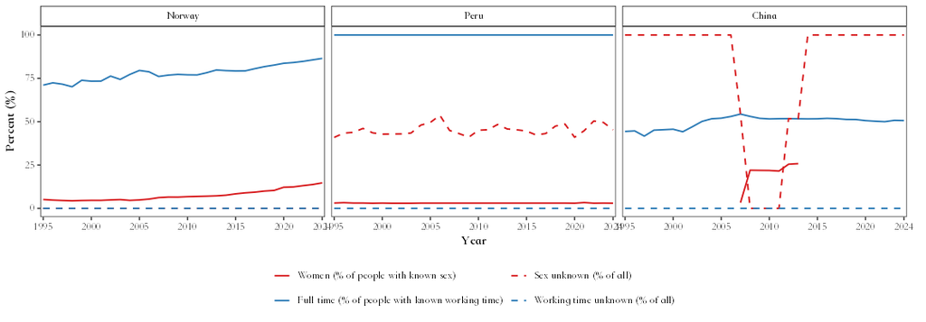

## 🎣 Catch per fisher: catch_per_fisher()

`catch_per_fisher()` divides the marine catch by the marine fishers (coastal, deep-sea and not specified), the inland catch by the inland fishers, and the whole catch by all fishers, as FAO did by region (FAO 2012, table 9). With `weights = "fte"`, fishers count as full-time equivalents with the weights of Scherrer et al. (2024): part time 60/95, occasional 15/95, full time and unknown 1.

```r
catch_per_fisher(c("Norway", "Iceland", "Peru", "Indonesia", "China", "India"), employment = employment,
                 label = "six")
catch_per_fisher("India", weights = "fte", employment = employment)
```

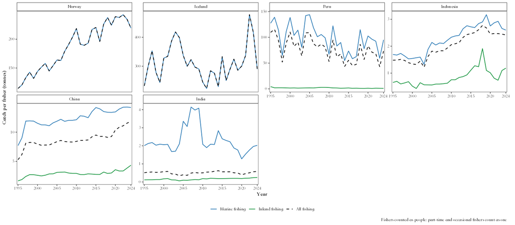

Marine catch per fisher in 2024 was 290 t in Iceland, 219 t in Norway and 95 t in Peru, but 2 to 3 t in India and Indonesia. Read it with the messages the function prints:

- **Workers of unspecified work area** are not counted as fishers. In China they are 49% of the workers (5.4 million), so its catch per fisher is too high, and its marine/inland split is not reliable (country note). Use the catch per fisher of all fishing for China.
- **Estimates carried forward.** All of India’s fishers are estimated values, and their number is the same as the year before in 9 of 30 years.
- **Coverage.** Norway leaves out foreign crews on Norwegian vessels (country note). Catch is recorded by the flag of the vessel.

## 📚 What others did with these data

- **Trade.** Studies of seafood trade networks mostly use UN Comtrade or BACI, because FAO trade by partner starts only in 2019 (Gephart and Pace 2015; Gephart et al. 2024). FAO’s own trade data are used for:
  - the share of production exported (FAO yearbook, appendix A-2; Golden et al. 2017);
  - apparent consumption by mass balance (Zhao et al. 2024);
  - unit values (Melnychuk et al. 2017);
  - re-export hubs (Asche et al. 2022).

  Their known problems are the ones above: product weight, caught and farmed mixed, re-exports, and mirror data (Dent and Clarke 2015; Watson et al. 2016).
- **Employment.** FAO presents trends, shares by work area and the composition by sex and working time (FAO 2024, 2026), and production per worker (FAO 2012). Scherrer et al. (2024) followed marine catch per fisher since 1950 with full-time equivalents. Surveys of small-scale fisheries found numbers close to FAO’s for full- and part-time fishers, with large differences in some countries (FAO, Duke University and WorldFish 2023).

The help pages of the functions give the full references.

## References

Asche, F. et al. (2022). China’s seafood imports - Not for domestic consumption? *Science* 375: 386-388. https://doi.org/10.1126/science.abl4756

Dent, F. and Clarke, S. (2015). *State of the global market for shark products.* FAO Fisheries and Aquaculture Technical Paper 590. https://www.fao.org/3/i4795e/i4795e.pdf

FAO (2012). *The State of World Fisheries and Aquaculture 2012.* https://www.fao.org/4/i2727e/i2727e.pdf

FAO (2024). *The State of World Fisheries and Aquaculture 2024.* https://doi.org/10.4060/cd0683en

FAO (2026). *The State of World Fisheries and Aquaculture 2026.* https://doi.org/10.4060/cd8357en

FAO, Duke University and WorldFish (2023). *Illuminating Hidden Harvests.* https://doi.org/10.4060/cc4576en

Gephart, J.A. and Pace, M.L. (2015). Structure and evolution of the global seafood trade network. *Environmental Research Letters* 10: 125014. https://doi.org/10.1088/1748-9326/10/12/125014

Gephart, J.A. et al. (2024). Globalization of wild capture and farmed aquatic foods. *Nature Communications* 15: 8026. https://doi.org/10.1038/s41467-024-51965-8

Golden, C.D. et al. (2017). Does aquaculture support the needs of nutritionally vulnerable nations? *Frontiers in Marine Science* 4: 159. https://doi.org/10.3389/fmars.2017.00159

Melnychuk, M.C., Clavelle, T., Owashi, B. and Strauss, K. (2017). Reconstruction of global ex-vessel prices of fished species. *ICES Journal of Marine Science* 74: 121-133. https://doi.org/10.1093/icesjms/fsw169

Scherrer, K.J.N., Rousseau, Y., Teh, L.C.L., Sumaila, U.R. and Galbraith, E.D. (2024). Diminishing returns on labour in the global marine food system. *Nature Sustainability* 7: 45-52. https://doi.org/10.1038/s41893-023-01249-8

Watson, R.A., Green, B.S., Tracey, S.R., Farmery, A. and Pitcher, T.J. (2016). Provenance of global seafood. *Fish and Fisheries* 17: 585-595. https://doi.org/10.1111/faf.12129

Zhao, K., Gaines, S.D., García Molinos, J., Zhang, M. and Xu, J. (2024). Effect of trade on global aquatic food consumption patterns. *Nature Communications* 15: 1412. https://doi.org/10.1038/s41467-024-45556-w